# ¿De qué va todo esto?

- En este taller discutiremos dos formas de trabajar mejor con R (o, al menos de hacer lo que muchos creemos que es mejor …) + Aprenderemos a **crear paquetes de R** de forma sencilla y rápida + Aprenderemos como **compartir el código** mediante el sistema de control de versiones `Git` trabajando en el repositorio`Github`.
- Y seremos más felices :-)

# Porque quisiera yo hacer paquetes?

- Para tener un código más + Robusto, + Extensible, + reproducible
- Básicamente para **hacer programas mejores** y **ahorrar tiempo**

# Porque trabajar con Sistemas de Control de Versiones?

- Para tener siempre la última versión
- Para compartir mi trabajo, con los demás pero *también conmigo* ya que puedo acceder siempre al último que he hecho desde cualquier equipo.
- Para disfrutar de la ayuda que me da el feed-back de una, dos, o quizás miles de personas.

# ¿Qué necesitamos para hacer paquetes?

- Nos harán falta algunos paquetes.

```r
if (! (require (DevTools))) install.packages ( "DevTools")
if (! (require (roxygen2))) install.packages ( "roxygen2")
if (! (require (testthat))) install.packages ( "testhat")
if (! (require (knitr))) install.packages ( "knitr")
```

# ¿Qué necesitamos para compartirlos por Git / Github?

- Creareamos una cuenta en `GitHub` (la web desde donde compartiremos el código).
- Instalaremos el programa `git` en nuestro ordenador

+ [Instrucciones para hacerlo] (http://r-pkgs.had.co.nz/git.html)

## Una nota sobre el “cómo”

- Hay varias formas de hacer paquetes.
- Clásica: Google _ “How to create R packages” _ + Bottom-Up: Creando cada componente y enlazándolas + Estilo de los manuales de CRAN o del seminario de John Fox
- À la “Hadley-Wickam” + Aprovechando herramientas de desarrollo contenidas en Rstudio + [Writing an R package from scratch] (https://hilaryparker.com/2014/04/29/writing-an-r-package-from-scratch/) + [Write an R Package from Scratch with Github] (http://www.r-bloggers.com/write-an-r-package-from-scratch-with-github/) + Ver: - [Su libro] (http://r-pkgs.had.co.nz/) - [Su curso] (http://courses.had.co.nz/12-devtools/) —

# Pensamos que queremos hacer

- En esta sesión trabajaremos *por ejemplo*: + Haga función sencilla con la que desea hacer un paquete + Considere un buen nombre para su paquete
- Un ejemplo naïve: `boxPlotWithDots` es una función que permite visualizar dos o más variables cuantitativas con puntos y / o boxplots.
- Veremos cómo empaquetarla pero empezamos *obteniéndola de un repositorio de GitHub*:

# Una función de ejemplo

```r
# source ( "https://raw.githubusercontent.com/alexsanchezpla/usefulFunctions/master/boxplotWithDots.R")
boxplotWithDots <- function (myExpres, lev, aTitle, groupLabels, addBoxplot=TRUE)
{
  beeswarm(myExpres~lev,
           ylab="Expression", xlab="Groups",
           main=aTitle,
           labels=groupLabels)
  if(addBoxplot)
    boxplot(myExpres~lev, add = T, names = c("",""), col="#0000ff22")
  # Segons un post de: https://www.r-statistics.com/2011/03/beeswarm-boxplot-and-plotting-it-with-r/
}
```

# Ejemplo de uso

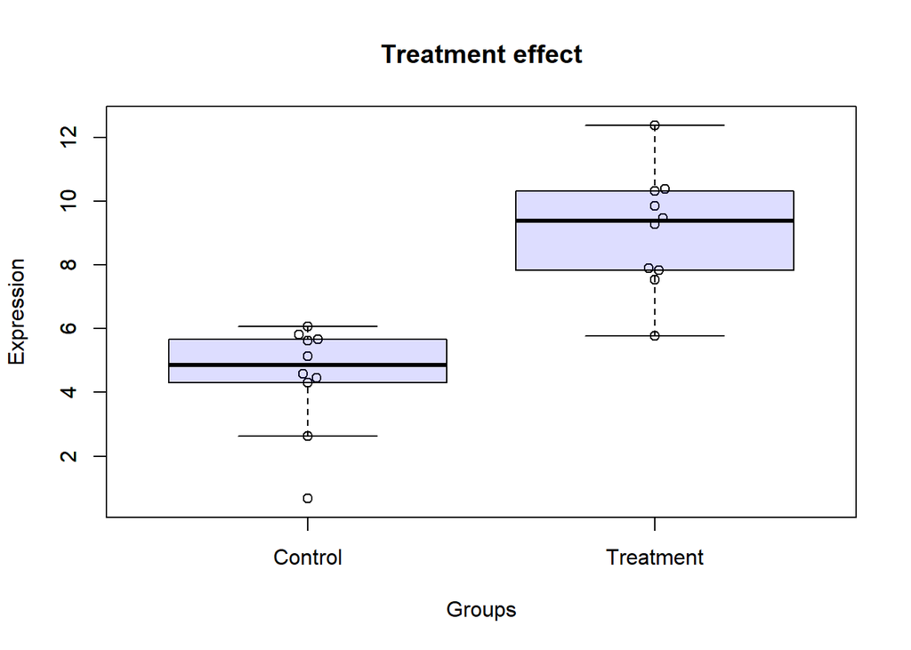

```r
require (beeswarm)
expres <-c (rnorm (10,5,2), rnorm (10,10,2))
trado <- as.factor (c (rep ( "CT", 10), rep ( "TR", 10)))
titulo <- "Treatment effect"
groupLab <- c ( "Control", "Treatment")
boxplotWithDots (myExpres = expres, lev = trado, aTitle = titulo, groupLabels = groupLab)
```